# lab9

Yuchen Song_201830360498 - Xuewen Wang_201830120252

2021/11/24

## The data

```r
load(url("http://www.openintro.org/stat/data/mlb11.RData"))
```

### Ex1

Scatter plot.

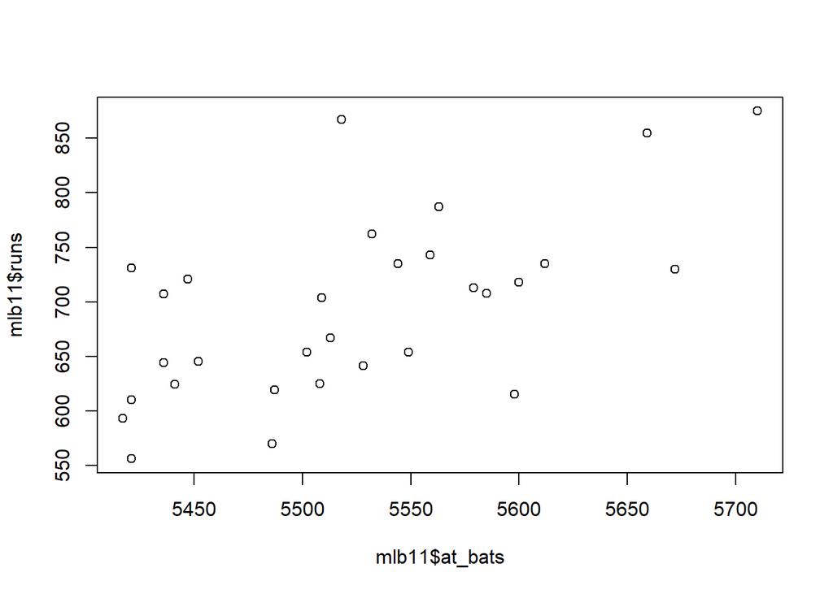

```r
plot(mlb11$at_bats,mlb11$runs)
```

```r
cor(mlb11$runs, mlb11$at_bats)
```

```
## [1] 0.610627
```

Yes, it is kind of linear, but the correlation is not strong enough.  
These two variables are quantitative/numerical variables, which are positively correlated, but as said above, they are not strongly correlated. Also, we can spot some obvious outliers from the imaginary regression line.

## Sum of squared residuals

### Ex2

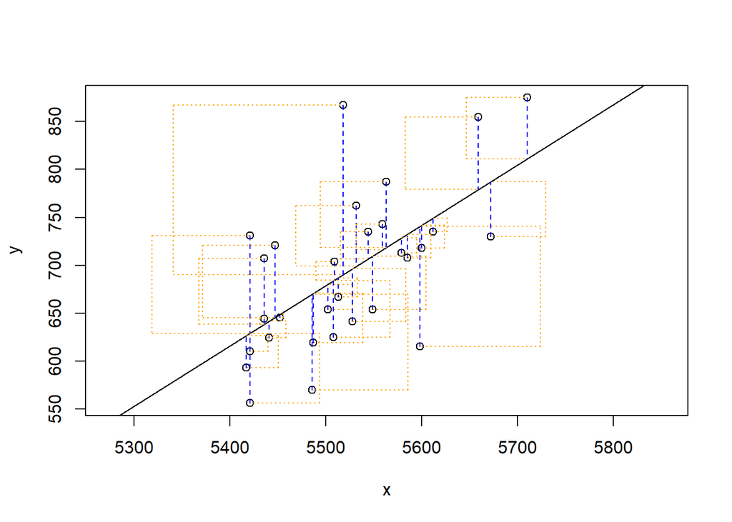

```
## Click two points to make a line.

## Call:
## lm(formula = y ~ x, data = pts)
##
## Coefficients:
## (Intercept)            x
##  -2789.2429       0.6305
##
## Sum of Squares:  123721.9
```

```r
plot_ss(x = mlb11$at_bats, y = mlb11$runs, showSquares = TRUE)
```

## The linear model

### Ex3

```r
m2 <- lm(runs ~ homeruns, data = mlb11)
summary(m2)
```

```
##
## Call:
## lm(formula = runs ~ homeruns, data = mlb11)
##
## Residuals:
##     Min      1Q  Median      3Q     Max
## -91.615 -33.410   3.231  24.292 104.631
##
## Coefficients:
##             Estimate Std. Error t value Pr(>|t|)
## (Intercept) 415.2389    41.6779   9.963 1.04e-10 ***
## homeruns      1.8345     0.2677   6.854 1.90e-07 ***
## ---
## Signif. codes:  0 '***' 0.001 '**' 0.01 '*' 0.05 '.' 0.1 ' ' 1
##
## Residual standard error: 51.29 on 28 degrees of freedom
## Multiple R-squared:  0.6266, Adjusted R-squared:  0.6132
## F-statistic: 46.98 on 1 and 28 DF,  p-value: 1.9e-07
```

The equation of the regression line is: $\hat{y}=415.2389+1.8345*homeruns$  
The slope tells us that whenever homeruns increse by a unit, there should be a 1.8345 units increase in the run.

## Prediction and prediction errors

### Ex4

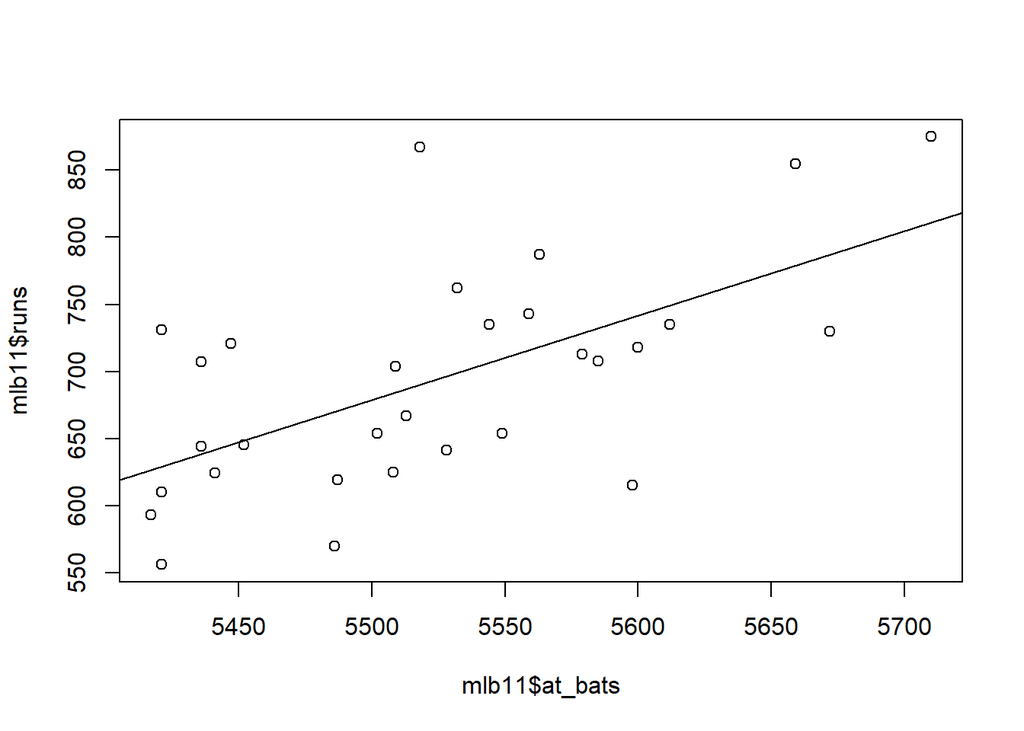

```r
plot(mlb11$runs ~ mlb11$at_bats)
abline(m1)
```

He would predict the runs at $\hat{y}=-2789.2429+0.6305*5585=732.0996$.  
The true runs for at-bats of 5585 is 708, which indicates that this is an overestimation, by 732.0996-708=24.0996.

```r
subset(mlb11,mlb11$at_bats==5585)["runs"]
```

```
##    runs
## 11  708
```

## Model diagnosticss

### Ex5

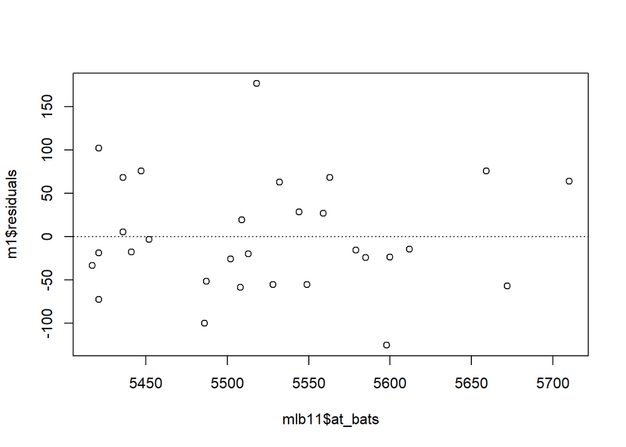

```r
plot(m1$residuals ~ mlb11$at_bats)
abline(h = 0, lty = 3)  # adds a horizontal dashed line at y = 0
```

The points are roughly evenly distributed around the dashed line, which implies that the model line is a good in Linearity, and that the two variables are linear correlated.

### Ex6

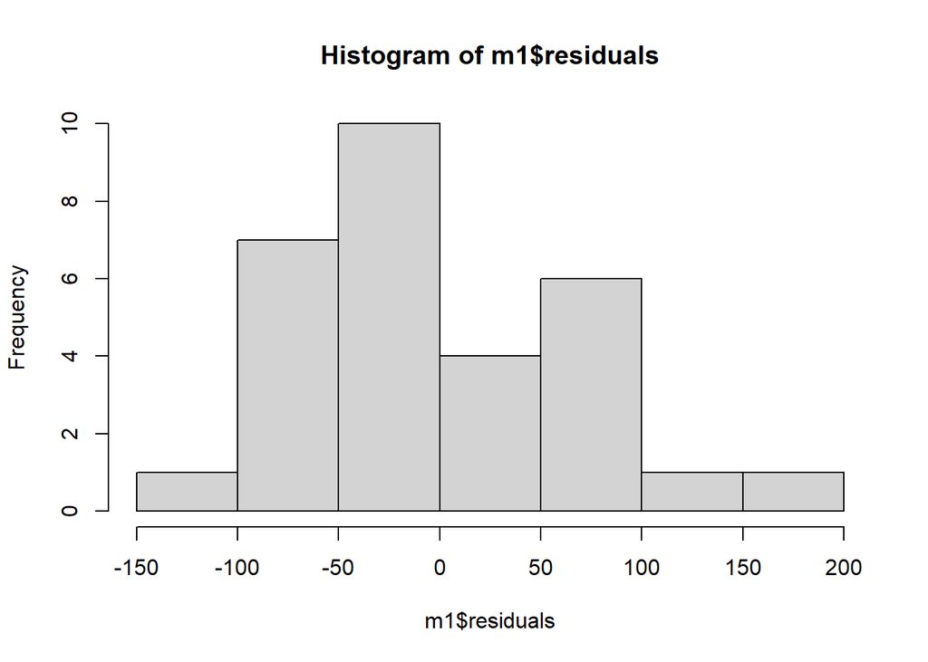

```r
hist(m1$residuals)
```

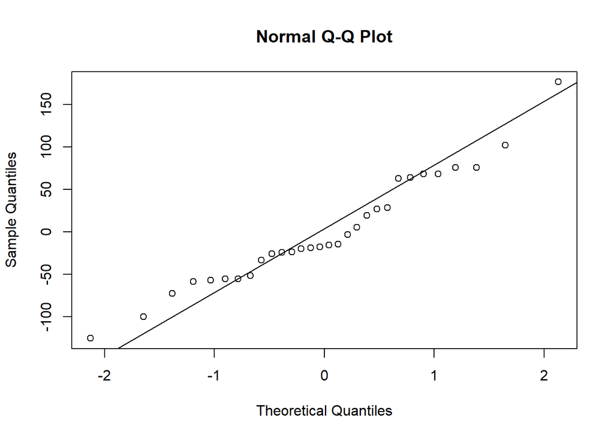

```r
qqnorm(m1$residuals)
qqline(m1$residuals)  # adds diagonal line to the normal prob plot
```

Based on the two plots, we can say that the nearly normal residuals condition appears to be met.

### Ex7

Based on the residual plot, we can spot that the residuals are distributed evenly around the line, so the constant variablilty condition has been met.

## Additional Exercises

### Ex8

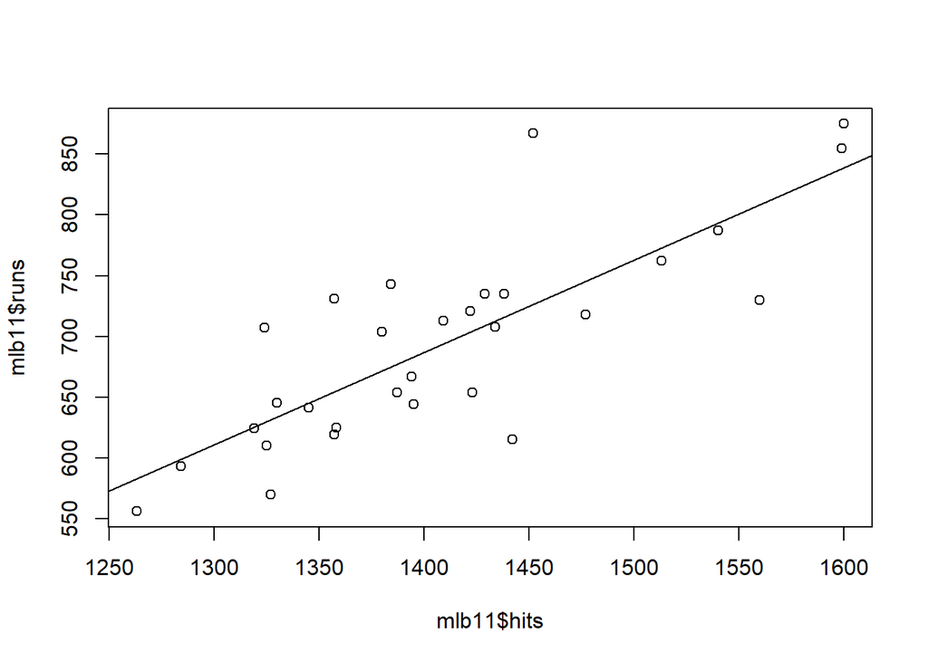

```r
plot(mlb11$hits,mlb11$runs)
m3 <- lm(runs ~ hits, data = mlb11)
abline(m3)
```

At the first glance, the two variables are roughly linearly correlated with each other.

### Ex9

```r
summary(m1)
```

```
##
## Call:
## lm(formula = runs ~ at_bats, data = mlb11)
##
## Residuals:
##     Min      1Q  Median      3Q     Max
## -125.58  -47.05  -16.59   54.40  176.87
##
## Coefficients:
##               Estimate Std. Error t value Pr(>|t|)
## (Intercept) -2789.2429   853.6957  -3.267 0.002871 **
## at_bats         0.6305     0.1545   4.080 0.000339 ***
## ---
## Signif. codes:  0 '***' 0.001 '**' 0.01 '*' 0.05 '.' 0.1 ' ' 1
##
## Residual standard error: 66.47 on 28 degrees of freedom
## Multiple R-squared:  0.3729, Adjusted R-squared:  0.3505
## F-statistic: 16.65 on 1 and 28 DF,  p-value: 0.0003388
```

```r
summary(m3)
```

```
##
## Call:
## lm(formula = runs ~ hits, data = mlb11)
##
## Residuals:
##      Min       1Q   Median       3Q      Max
## -103.718  -27.179   -5.233   19.322  140.693
##
## Coefficients:
##              Estimate Std. Error t value Pr(>|t|)
## (Intercept) -375.5600   151.1806  -2.484   0.0192 *
## hits           0.7589     0.1071   7.085 1.04e-07 ***
## ---
## Signif. codes:  0 '***' 0.001 '**' 0.01 '*' 0.05 '.' 0.1 ' ' 1
##
## Residual standard error: 50.23 on 28 degrees of freedom
## Multiple R-squared:  0.6419, Adjusted R-squared:  0.6292
## F-statistic:  50.2 on 1 and 28 DF,  p-value: 1.043e-07
```

The $R^2$ for runs and hits is 0.6419, while the $R^2$ for runs and at_bats is 0.3729, so this relationship is stronger than that of the first model.  
Yes, in most of the time, the model with larger R_squared is a better fitting of the data, in other words, the prediction using this model is more accurate.

### Ex10

```r
plot(mlb11$wins,mlb11$runs)
cor(mlb11$wins,mlb11$runs)
```

```
## [1] 0.6008088
```

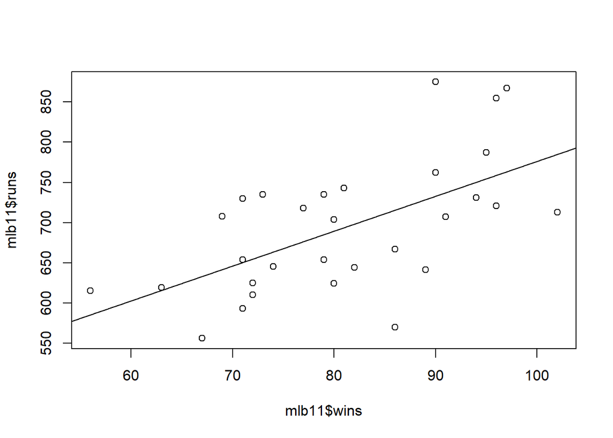

```r
m4 <- lm(runs ~ wins, data = mlb11)
abline(m4)
```

```r
summary(m4)
```

```
##
## Call:
## lm(formula = runs ~ wins, data = mlb11)
##
## Residuals:
##      Min       1Q   Median       3Q      Max
## -145.450  -47.506   -7.482   47.346  142.186
##
## Coefficients:
##             Estimate Std. Error t value Pr(>|t|)
## (Intercept)  342.121     89.223   3.834 0.000654 ***
## wins           4.341      1.092   3.977 0.000447 ***
## ---
## Signif. codes:  0 '***' 0.001 '**' 0.01 '*' 0.05 '.' 0.1 ' ' 1
##
## Residual standard error: 67.1 on 28 degrees of freedom
## Multiple R-squared:  0.361,  Adjusted R-squared:  0.3381
## F-statistic: 15.82 on 1 and 28 DF,  p-value: 0.0004469
```

```r
plot(mlb11$bat_avg,mlb11$runs)
cor(mlb11$bat_avg,mlb11$runs)
```

```
## [1] 0.8099859
```

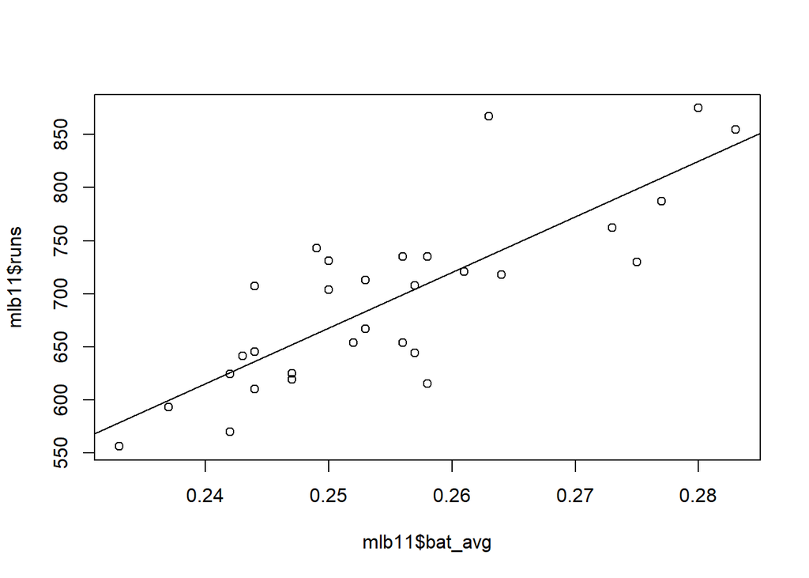

```r
m5 <- lm(runs ~ bat_avg, data = mlb11)
abline(m5)
```

```r
summary(m5)
```

```
##
## Call:
## lm(formula = runs ~ bat_avg, data = mlb11)
##
## Residuals:
##     Min      1Q  Median      3Q     Max
## -94.676 -26.303  -5.496  28.482 131.113
##
## Coefficients:
##             Estimate Std. Error t value Pr(>|t|)
## (Intercept)   -642.8      183.1  -3.511  0.00153 **
## bat_avg       5242.2      717.3   7.308 5.88e-08 ***
## ---
## Signif. codes:  0 '***' 0.001 '**' 0.01 '*' 0.05 '.' 0.1 ' ' 1
##
## Residual standard error: 49.23 on 28 degrees of freedom
## Multiple R-squared:  0.6561, Adjusted R-squared:  0.6438
## F-statistic: 53.41 on 1 and 28 DF,  p-value: 5.877e-08
```

From what has been demonstrated above, we can say that the best variable to predict the runs is bat_avg, with R_Square of 0.6561 and cor of 0.8099859.